# Info 201 Project

# Introduction

Every individual is experiencing the effects of the Coronavirus pandemic in some way, shape, or form, just as we all bear responsibility for slowing its spread. Nine months of lockdown, well over a quarter of a million Americans dead, and millions more infected have lead to one of the largest mass casualty events in our history. A brutal virus that relegates individuals to their homes is the enemy of the small business, with tens of thousands closing in the wake of our economic downturn. This report will look at how the Coronavirus Pandemic has affected unemployment and revenue, and how that effect has been felt across the myriad job sectors in the United States. We will be looking at which employment sectors have been hit the hardest by the virus, and when the worst months regarding revenue losses and jobless claims were.

## Summary

Of the **19** job sectors in our dataset, all saw revenue changes over the pandemic. During the beginning of the pandemic, with mandatory lockdowns and no stimulus bill on the horizon, both the US and global economies cratered. At its highest, **99.5%** of businesses within a sector were negatively affected by COVID-19 in a week; at its lowest, a mere **0.2%** of businesses saw a negative revenue effect. With frequent weekly reports (the information sector has filed **104** weekly reports since the pandemic), and a standard error of **19.13** - we can see the devastation this pandemic has had on the United States economy.

## Aggregate Table

Aggregate Table of Job Sectors

| NAICS_SECTOR | AVERAGE_PERCENT | MEDIAN_PERCENT | MIN_PERCENT | MAX_PERCENT |
| --- | --- | --- | --- | --- |
| - | 19.76852 | 11.00 | 0.3 | 97.0 |
| Arts | 19.73704 | 9.65 | 0.4 | 96.9 |
| Construction | 19.73208 | 10.40 | 0.2 | 97.9 |
| Educational Services | 21.22843 | 10.15 | 0.9 | 96.5 |
| Finance | 18.92170 | 6.55 | 0.2 | 99.5 |
| Food Services | 20.82130 | 11.30 | 0.5 | 92.7 |
| Health Care | 20.65556 | 11.45 | 0.3 | 97.1 |
| Information | 20.06346 | 9.30 | 0.7 | 98.4 |
| Management | 41.80233 | 36.70 | 8.8 | 97.5 |
| Manufacturing | 20.27009 | 12.50 | 0.3 | 98.0 |
| Mining | 21.01735 | 9.15 | 1.4 | 97.4 |
| Other Services | 20.25327 | 11.10 | 0.2 | 95.6 |
| Professional Services | 19.13333 | 8.80 | 0.2 | 98.3 |
| Real Estate | 19.35238 | 7.90 | 0.4 | 97.8 |
| Retail Trade | 20.30556 | 12.20 | 0.2 | 97.3 |
| Transportation | 19.60000 | 10.30 | 0.4 | 95.9 |
| Utilities | 32.45085 | 14.80 | 2.8 | 98.7 |
| Waste Management | 19.95810 | 10.50 | 0.6 | 97.0 |
| Wholesale Trade | 19.86481 | 10.90 | 0.2 | 97.6 |

The Aggregate Table calculates and compares the average, median, minimum, and maximum aggregated percentage change in revenue in each business sector during the week of Oct 04. The table reveals that the average percentage change are constantly higher than the median, implying that there are more businesses having higher percentage of change. There’s also a great difference between the minimum and the maximum percentage of revenue change within each sector, reflecting the various level of impact each business experienced.

## Chart 1 (Sector Bar Chart):

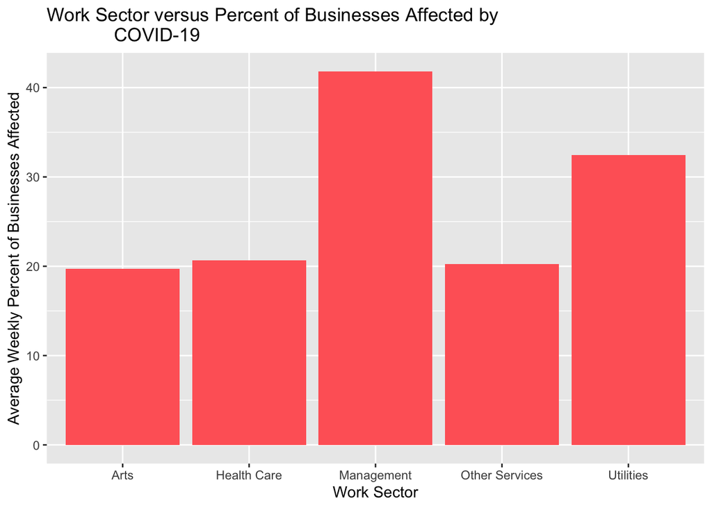

This chart was generated to show the relationship between a job sector and the effect COVID-19 has had within businesses in that work sector.

From the chart we can see that the Management and Utilities sectors were hit the hardest with the highest average weekly percentage of businesses affected.

The chart also shows that within the 5 sectors chosen for the report, none of them were spared from the effects of COVID-19 as all of them were affected to a certain extent.

## Chart 2 (Sector Boxplot):

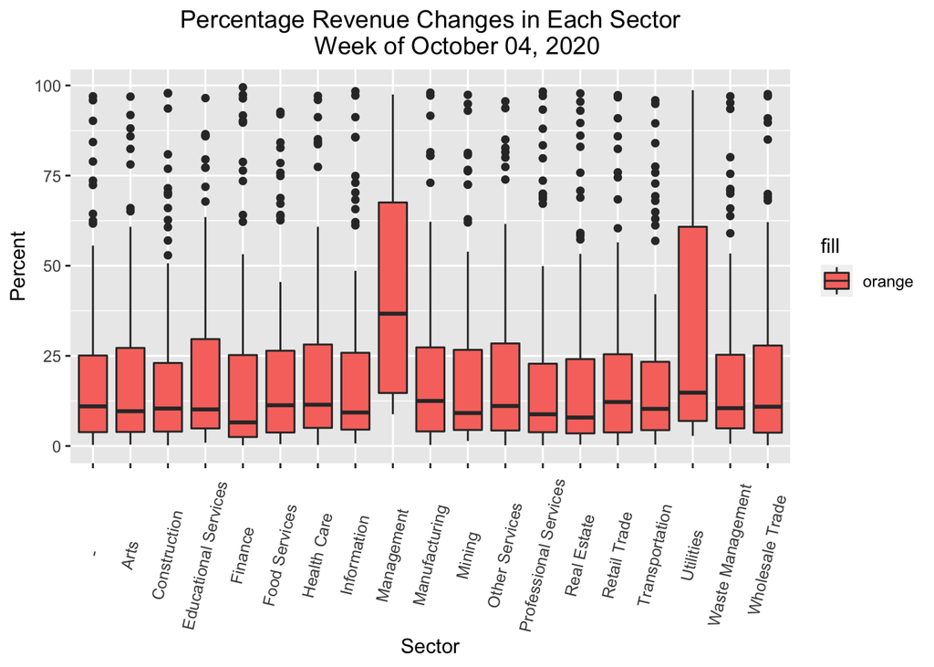

This boxplot was generated to further explore the variance within each job sector as well as across each sector as a result of COVID-19 in October.

From the plot, we can see how the effect varies across the board, especially when comparing with the median of that sector. Utilities had the largest variance within the sector, where many businesses had high percentage of being effected compared to the sector’s median. The entire Management job sector was affected the most with almost no outliers, high median percentage of change, and high percentage of change for each business in the sector.

Most of other sectors seems to recover from the pandamic, with the median of change falling below 13 percent.

## Chart 3 (Unemployment Scatter Plot)

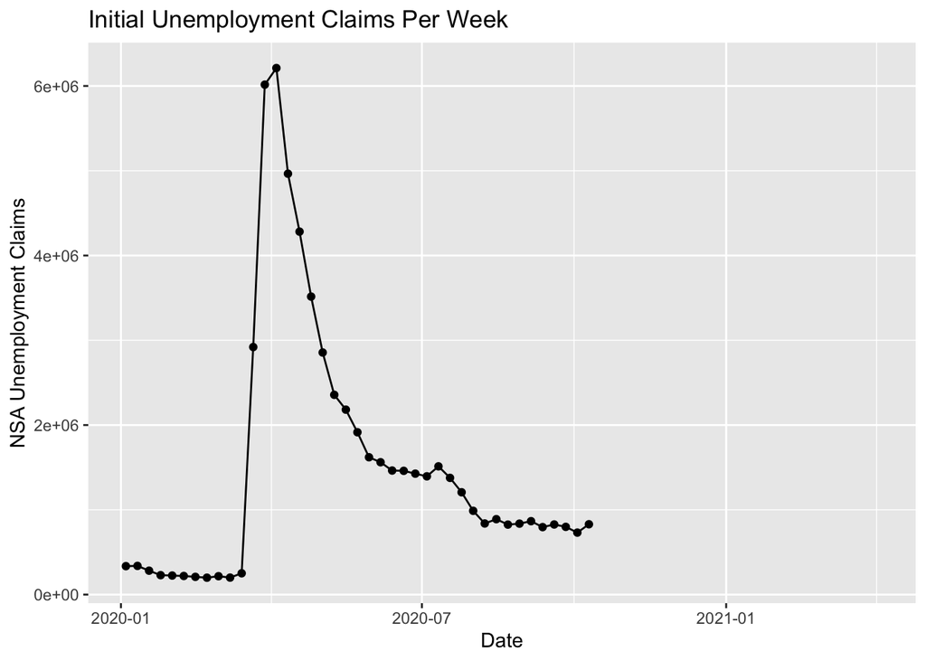

This chart was generated to show the relationship of Non Seasonally Adjusted (NSA) unemployment claims per week in the United States since January 4th, 2020.

From this chart we can clearly see where the pandemic occurred, with a massive spike in unemployment claims that has been steadily decreasing since the initial peak in the early pandemic. What this chart does not show are the continued unemployment claims, the delta between these two would show the amount of Americans choosing to exit the workforce compared to those still searching for employment